# ANOVA

Manpreet S. Katari

October 23, 2019

## $\chi^{2}$ distribution

A $\chi^{2}$ distribution is when you take the sum of squared random values selected from a normal distribution. The degree of freedom, $k$ is simply the number of random values.

$$Q = \sum\limits_{i=1}^{k} Z_{i}^{2}$$

Let’s simulate this data to see what it looks like when k = 10, 5, and 1 and the values are retrieved from a standard normal distribution.

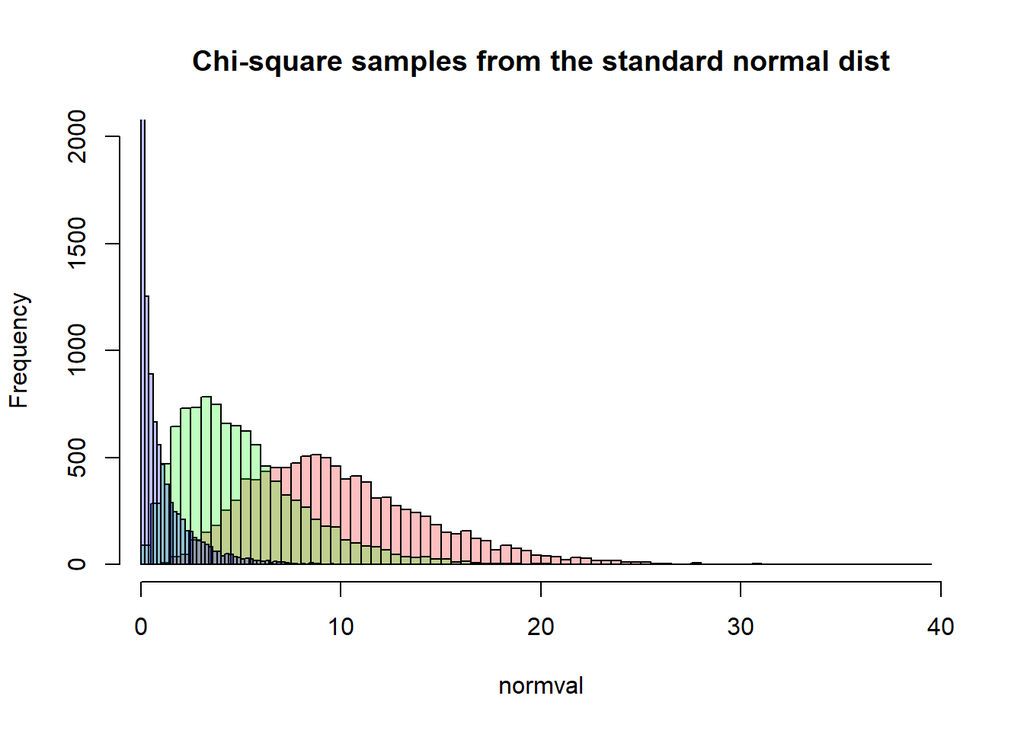

```r
#################

# Sample size k = 10 ==> Chi-squared degrees of freedom = 10
chik=10
normval=numeric()
for (i in 1:10000) {  # repeat this 10000 times

  # Randomly sample k items from the standard normal distribution
  # then take the sum of squared values of the random samples
  normval[i]=sum(rnorm(chik)**2)
}

# make a histogram of the results
hist(normval, breaks=100, # make 100 bins on the x-axis
     col=rgb(1,0,0,.25),  # make it red, with 25% transparency
                          # this allows us to show multiple histograms on the same plot
     ylim=c(0,2000),      # set the limits of the y-axis
     main = "Chi-square samples from the standard normal dist"
    )
# Sample size k = 5 ==> Chi-squared degrees of freedom = 5
chik=5
normval=numeric()
for (i in 1:10000) {
  normval[i]=sum(rnorm(chik)**2)
}

# the `add` directive adds the new histogram to the old plot
hist(normval, breaks=75,          # reduce the number of bins since this distribution
                                  # is squished to the left
     col=rgb(0,1,0,.25), add=T)   # green, with 25% transparency

# Sample size k = 1 ==> Chi-squared degrees of freedom = 1
chik=1
normval=numeric()
for (i in 1:10000) {
  normval[i]=sum(rnorm(chik)**2)
}

hist(normval, breaks=50,          # use even fewer bins
     col=rgb(0,0,1,.25), add=T)   # blue, with 25% transparency
```

To compare two $\chi^{2}$ distributions, we can simply take a ratio of them (taking into account their degree of freedom). This distribution is called an **$F$-distribution** and the **ratio** is the **$F$-statistic**. (The $F$-distribution is named after the statistician Ron Fisher.)

Let’s first see what it would look like if the the means of the two populations that are being sampled are **equal**.

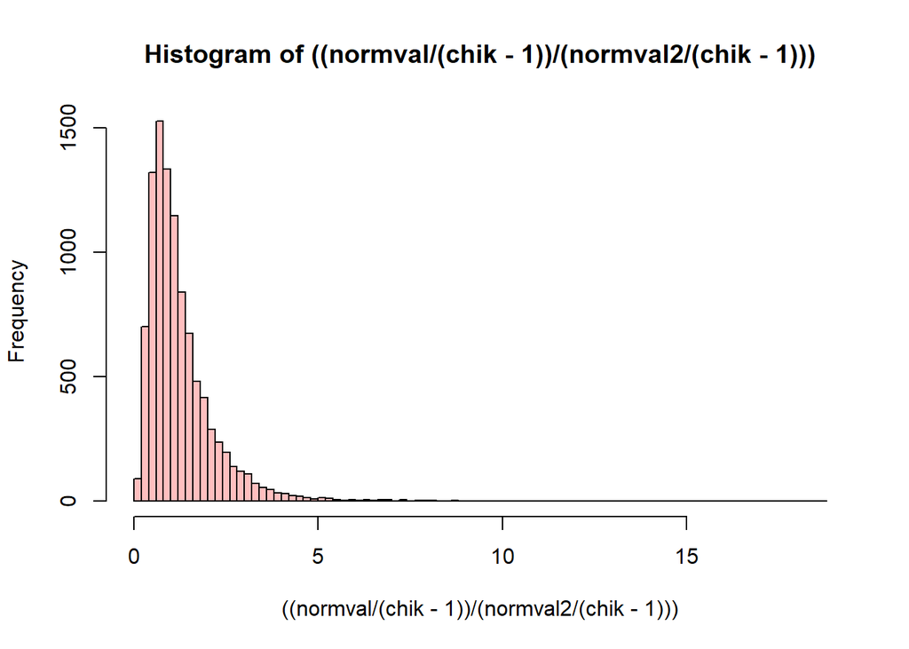

```r
chik=10
normval=numeric()
normval2=numeric()
for (i in 1:10000) {
   normval[i]=sum(rnorm(chik)**2)
   normval2[i]=sum(rnorm(chik)**2)

}

# since the values are sampled from the same distribution,
# the ratios are centered around 1
hist(((normval/(chik-1))/(normval2/(chik-1))), breaks=100, col=rgb(1,0,0,.25))
```

What if the means of our normal distributions are different? Let’s superimpose onto the above histogram another one for comparison that shows the same ratio for data sampled from normal distributions with different means: the standard normal and a normal distribution with mean = 2 and SD = 1.

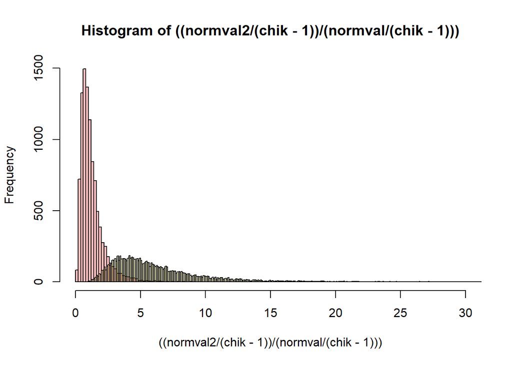

```r
chik=10
normval=numeric()
normval2=numeric()
for (i in 1:10000) {
  # take two sets of sample of size 10 from the standard normal distribution
   normval[i]=sum(rnorm(chik)**2)
   normval2[i]=sum(rnorm(chik)**2)

}

# now plot the ratios of them -- note that we didn't bother to store the
# intermediate result since we don't need to do anything with it later.
hist(((normval2/(chik-1))/(normval/(chik-1))),
     breaks=100, ylim=c(0,1500), # the second hist is really tall compared to the first!
                                 # b/c the ratio is less than one and most of the density
                                 # is very close to the mean
     xlim=c(0,30),
     col=rgb(1,0,0,.25))


chik=10
normval=numeric()
normval2=numeric()
for (i in 1:10000) {
   normval[i]=sum(rnorm(chik)**2)
   normval2[i]=sum(rnorm(chik, mean=2)**2)


}

hist(((normval2/(chik-1))/(normval/(chik-1))),
     breaks = 500, col=rgb(1,1,0,.25), add=T)    # need a lot less breaks here
```

Remember that variance is essentially a sum of squares as discussed above. So now we have the ability to compare two different variances and use a statistic to determine if they are significantly different.

# ANOVA

The Suggested Reading for ANOVA is:

- Grafen and Hails - Chapter 1
- Dalgaard - Chapter 7

I took this example from the following Khan Academy videos:

- [Calculating SST](https://www.youtube.com/watch?v=EFdlFoHI_0I)
- [Calculating SSW and SSB](https://www.youtube.com/watch?v=j9ZPMlVHJVs)
- [Hypothesis Testing](https://www.youtube.com/watch?v=Xg8_iSkJpAE)

In the previous lectures we discussed how we can use the $t$-test to determine if two sample distributions come from the population with the same mean. In many cases, we will have **multiple** sample groups and we will want to ask a similar question: **Are the means of the different samples the same ?**

To answer this question we will look at a very simple case with three conditions, **a, b, and c** and ask if their means are significantly different.

```r
a=c(3,2,1)
b=c(5,3,4)
c=c(5,6,7)

anova_mat = cbind(a,b,c)
anova_mat # take a look at what the data frame looks like
```

```
##      a b c
## [1,] 3 5 5
## [2,] 2 3 6
## [3,] 1 4 7
```

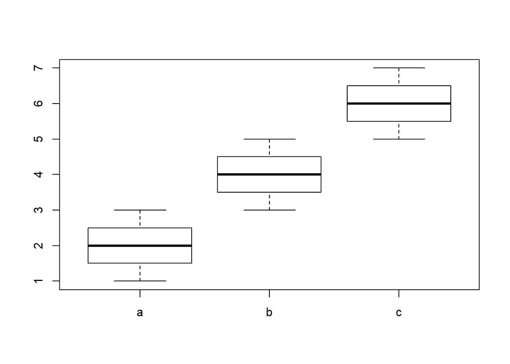

```r
boxplot(as.data.frame(anova_mat))
```

Looking at the boxplots above, it is clear to see that their means are indeed different. So the question we want to ask is whether the differences are significant.

Instead of looking at the difference between the sample means, as we did with $t$-test, we will look at variances. There are three different variances that we can calculate:

- **$SST$** ( Total Sum of Squares ) = variation of all the points to the overall mean.
- **$SSW$** ( Within Group Sum of Squares ) = variation of the data within each group.
- **$SSB$** ( Between Group Sum of Squares ) = variation of the group mean to the overall mean.

We also need the **degrees of freedom**. Given that you know the average, how many values you need to know? It’s simply one less than the number of items being considered for each comparison, because using the mean you can always calcuate the last value.

To calculate $SST$, we simply take the difference of all the values from the overall mean, square them, and then take the sum.

```r
anova_mat_mean = mean(anova_mat)

SST = sum((anova_mat - anova_mat_mean)**2)
SST
```

```
## [1] 30
```

Since this is a sample of the entire population, our degree of freedom is the total number of values minus one.

```r
SST_df = length(anova_mat)-1
SST_df
```

```
## [1] 8
```

SSW ( Within Group Sum of Squares ) = variation of the data within each group. Here we calculate the variation of each point relative to the mean of its own group and simply add up the squared differences across all the groups.

```r
anova_mat_col_mean = colMeans(anova_mat)
anova_mat_col_mean
```

```
## a b c
## 2 4 6
```

```r
SSW=0
for ( i in 1:nrow(anova_mat)) {
  SSW = SSW + sum((anova_mat[i,]-anova_mat_col_mean)**2)
}
SSW
```

```
## [1] 6
```

When calculating the degree of freedom, remember that we calculated the sum of squared differences relative every group’s mean, so if we have *m* groups and *n* samples in each group, then `df = m*(n-1)`.

```r
SSW_df = ncol(anova_mat)*(nrow(anova_mat)-1)
SSW_df
```

```
## [1] 6
```

SSB ( Between Group Sum of Squares ) = variation of the group mean to the overall mean. First, we find the sum of squared differences for each group mean compared to the overall mean. We also multiply by the number of values in the group to create a SS comparison for each of the original datapoints.

```r
SSB = 0

for ( i in 1:length(anova_mat_col_mean)) {
 SSB = SSB + (nrow(anova_mat)*(anova_mat_col_mean[i]-anova_mat_mean)^2)
}
SSB
```

```
##  a
## 24
```

For calculating between group degree of freedom, remember that if we have *m* groups, so it is simply *m-1*.

```r
SSB_df = ncol(anova_mat)-1
SSB_df
```

```
## [1] 2
```

Finally since our variance calculations are sums of squares, they can be considered to follow a $\chi^2$ distribution. If the variance within the groups is the same and if the means of the groups are the same, then the variance between the groups should be the same as within the groups.

We can take this one step further and say that if the variance *between* the groups is *greater* than *within* the groups, then the means of the groups are different. Any change in the ratio would fit an *F-distribution* and a $p$-value can be calculated.

```r
Fstat = (SSB/SSB_df) / (SSW/SSW_df)
pf(Fstat, 2, 6, lower.tail = F)
```

```
##     a
## 0.008
```

We can confirm our results using the **aov** function.

```r
library(reshape2)

# we use the melt function to reshape the data frame into three columns:
# Var1 = the three groups, indexed as 1, 2, 3
# Var2 = the three groups, indexed by their variable name
# value = the value of each data point
anova_mat.melt = melt(anova_mat)
anova_mat.melt  # look at this new data structure
```

```
##   Var1 Var2 value
## 1    1    a     3
## 2    2    a     2
## 3    3    a     1
## 4    1    b     5
## 5    2    b     3
## 6    3    b     4
## 7    1    c     5
## 8    2    c     6
## 9    3    c     7
```

```r
# look at the result of the ANOVA command `aov`
# the syntax is to do the analysis of the values in response to the factors (groups a,b,c)
summary(aov(anova_mat.melt$value ~ anova_mat.melt$Var2))
```

```
##                     Df Sum Sq Mean Sq F value Pr(>F)
## anova_mat.melt$Var2  2     24      12      12  0.008 **
## Residuals            6      6       1
## ---
## Signif. codes:  0 '***' 0.001 '**' 0.01 '*' 0.05 '.' 0.1 ' ' 1
```